# StochProcess..Basics slides

## Stochastische Prozesse und eine kurze Einführung in Monte-Carlo Simulationen

## Was ist ist ein stochastischer Prozess?

Wikipedia beschreibt einen stochastischen Prozess als

die mathematische Beschreibung von zeitlich geordneten, zufälligen Vorgängen.

**"Defintion":**

Sei $(\Omega, P, F)$ ein Wahrscheinlichkeitsraum, $T$ eine Indexmenge (üblicherweise T=N oder T=R). Eine Folge von von Zufallsvariablen $X_t$ mit $t \in T$ mit $X_t : \Omega \to R$ einen stochastischen Prozess.

**Beispiele**

- Aktienkurse, Zinsen, Fx-Kurse
- Warteschlange an der Supermarktkasse
- Arbeitslosenzahlen
- ...

Eine Realisierung / Beobachtung eines Stochastischen Prozess nennt man auch **Pfad**.

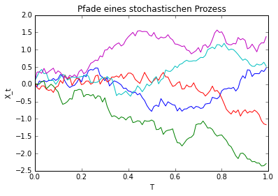

```python
dt = 1./100.
T = np.arange(0, 1, dt)
for i in range(0,5):
    X = np.cumsum(np.sqrt(dt) * np.random.randn(T.shape[0]))
    plt.plot(T,X)
plt.xlabel("T")
plt.ylabel("X_t")
plt.title("Pfade eines stochastischen Prozess")
```

### Wiener Prozess

Eine besondere Klasse ist der Wiener Prozess. Er hat folgende Eigenschaften:

- $W(0) = 0$
- $W(t_2) - W(t_1) \sim N(0,t_2-t_1)$
- Differenzen sind i.i.d

## Stochastische Differentialgleichungen

In der Bewertung von Finanzinstrumente spielen stochastiche Prozesse eine wichtige Rolle.

### Beispiel Call Option

Wir haben eine Aktie, den Aktienkurs den wir beobachten folgt einem stochastischen Prozess $S_t$.

Eine Call-Option gibt dem Optionshalter das Recht zum Zeitpunkt $T$ (OptionExpiry) die Aktie zu einem festgelegten Kurs $K$ (Strike) zu kaufen.

Zum Ausübungszeitpunkt ist der Wert der Option mit $V(T) = \max(0.0, S_T-K)$ gegeben.

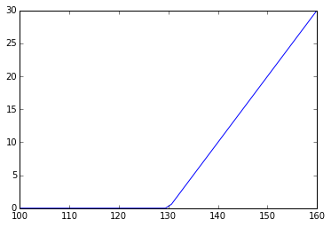

```python
K = 130
S_T = np.linspace(100, 160, 50)
plt.plot(S_T, np.fmax(S_T-K, 0) )
```

### Aber was ist der Wert zum heutigen Zeitpunkt t=0?

Unter gewissen Vorraussetzungen kann man zeigen, das der heutige Wert den erwarteten abdiskontierten Auszahlung entspricht

$P(0,0) * V(0) = E[P(0,T) V(T, S_T) | F_0]$

**Vorraussetzungen:**

- kein Arbitrage
- vollständiger Markt

**Grobskizze**

- Replikationsportfolio aus handelbaren Assets (bei BS: die Aktie und Bankaccount)
- Da kein Arbitrage Preis des Replikationsportfolio muss Preis des Derivates entsprechen
- Unter einem bestimmen Wahrscheinlichkeitsmaß (risikoneutrale) sind alle diskontierte handelbare Assets Martingale

**Wie können wir den Erwartungswert berechnen?**

Wir müssen dazu die Verteilung von V(T, S_T) kennnen. Die Verteilung ist abhängig vom Prozess.

### Black Scholes SDGL

Mit einer stochastischen Differentialgleichung wird die *Dynamik* des Prozesses beschrieben. Üblicherweise hat eine SDGL die Form

$ dS_t = \mu(t, S_t) dt + \sigma(t, S_t) dW_t$

mit dem Wiener prozess $W_t$.

Die Änderung des Prozesses von $t$ nach $t+\delta t$ für sehr kleine (unendlich kleine) $\delta t$ wird mit dieser Formel beschrieben. Es besteht aus einem deterministischen Teil $\mu(t, S_t)dt$ und einem stochastishen Teil beschrieben $\sigma(t, S_t) dW$.

Ein sehr bekanntes Modell ist das Black-Scholes Model mit der SDGL:

$ dS_t = r S_t dt + \sigma S_t dW$

mir dem risikolosen Zins $r$.

Für dieses Modell gibt es eine Lösung für die Gleichung

$S(t) = S_0\exp((r-\frac{\sigma^2}{2})t+\sigma W_t)$

In diesem Model sind die relativen Veränderung von S_0 nach S_t lognormal verteilt.

$\log(\frac{S_t}{S_0}) = (r-\frac{\sigma^2}{2})t+\sigma W_t$

In diesem Modell gibt es sogar geschlossene Formen für die Preise von einer Calloption:

$V(0) = S_0\Phi(d1) - K \exp(-rT) \Phi (d2) $

mit $d1=\frac{\log{\frac{S_0}{K}}+(r + \frac{\sigma^2}{2})T}{\sigma\sqrt{T}}$, $d2=d1-\sigma\sqrt{T}$ und $\Phi$ die Verteilungsfunktion der Standardnormalverteilung.

**Was kann man machen wenn es keine geschlossene Formel gibt?**

### Monte Carlo Methoden

Wie lassen sich Erwartungswerte schätzen?

**Mittelwert**

Sei $X_i$ unabhängig und identisch verteilte Zufallsvariablen mit $E[X_i] = \mu$. Dann ist

$\hat{\mu} = \frac{1}{n} \sum_i^n X_i $

ein erwartungstreuer und konsistenter Schätzer.

#### Beispiel 1:Berechnung von $\pi$ mit MC

- Dartwurf auf ein Quadrat 2 x 2
- In dem Quadrat ist der Einheits-Kreis gezeichnet
- $X_i = 1$, fall der Dart innerhalb des Kreises landet und sonst Null.
- Wir nehmen dass wir nicht "zielen" und somit jeder Punkte auf der Fläche mit der gleichen Wahrscheinlichkeit getroffen werden. Die Würfe sind unabhängig und die Wahrscheinlichkeit das ein Dart im Kreis landet liegt bei $\frac{1}{4}\pi$.

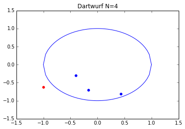

```
Pi = 3.000000
```

```python
MCSimulation1(4)
```

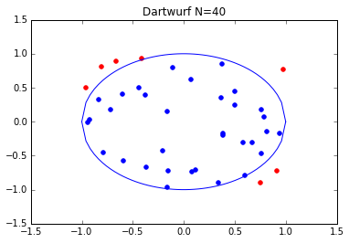

```
Pi = 3.300000
```

```python
MCSimulation1(40)
```

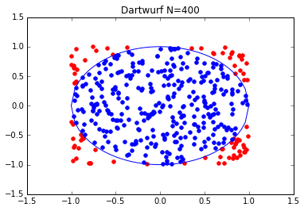

```
Pi = 3.150000
```

```python
MCSimulation1(400)
```

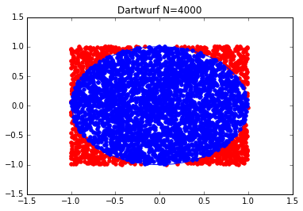

```
Pi = 3.147000
```

```python
MCSimulation1(4000)
```

### Beispiel 2. Calloption mit Monte Carlo Simulation

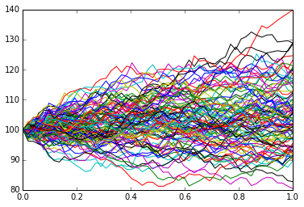

```python
t, S1 = pathGeneration(100, 100, 0.1, 0.03, 1, 1/52.)

for i in range(0, 100):
    plt.plot(t, S1[i,:])
```

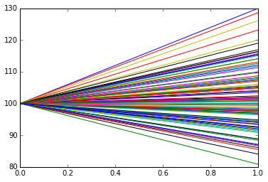

```python
N = 10000
t, S = pathGeneration(N, 100, 0.1, 0.03, 1, 1)

for i in range(0, 100):
    plt.plot(t, S[i,:])
```

### Güte der Simulation in Abhängigkeit der Sitchprobe

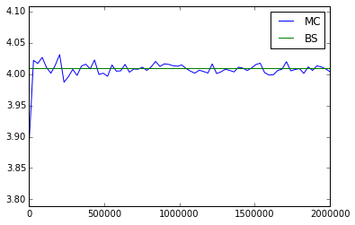

```python
N = np.linspace(100,2e6, 70)
V_MC = np.zeros(N.shape)
V_BS = np.zeros(N.shape)
V_BS[:] = BlackScholesCall(100, 103, 0.03, 0.1, 1)
for i in range(N.shape[0]):
    t, S = pathGeneration(N[i], 100, 0.1, 0.03, 1, 1)
    V_MC[i] = np.mean(payOff(S[:,-1], 103, 1, 0.03))

plt.plot(N,V_MC)
plt.plot(N,V_BS)
plt.ylim(np.min(V_MC)-0.1, np.max(V_BS)+0.1)
plt.legend(["MC", "BS"])
```

```python
import pandas as pd
pd.DataFrame(V_MC, index=N).T
```

[output not shown]

### Varianz in Abhängigkeit der Sitchprobe

```python
pd.DataFrame(V_MC, index=N).T.var()
```

[output not shown]